# Beginner Python and Math for Data Science

## Lecture 0 - Part 1

### Get Up and Running with Python and Jupyter Notebooks

**Purpose:** The purpose of this lecture is to explain the process of installing Python through the Anaconda Distribution and ensure everything is working by running some early diagnostics and checks.

**At the end of this lecture you will be able to:**

1. Understand what Anaconda is and how it is helpful for us as Data Scientists
2. Understand how to download Python based on your operating systemem
3. Verify Jupyter Notebooks and Python are working
4. Create a new Jupyter Notebook and writing a simple program
5. Save and open an existing Jupyter Notebook and execute the contained code

```python
# table of contents
```

```python
# Ignore for now (this is a package for importing images that are maintained when converting the .ipynb file)
from IPython.display import Image
```

# 0.1 Anaconda Distribution:

Before we start programming, we must download Python which is the chosen language of this course. It is possible to download Python through the main website [here](https://www.python.org/). However, we will use the Anaconda Distribution to download Python which can be found [here](https://www.anaconda.com/download/#macos).

Anaconda is a powerful and [open source](https://en.wikipedia.org/wiki/Open-source_software) platform that allows users to do Data Science and Machine Learning among other programming tasks in Python. The [Anaconda Distribution](https://www.anaconda.com/distribution/) comes with the following components:

1. **Anaconda Navigator**: This is the portal accessible on your desktop (also referred to as a Desktop [GUI](https://en.wikipedia.org/wiki/Graphical_user_interface)) which you will be able to access after successfully downloading Anaconda. From this portal, you can start programming in a Jupyter Notebook, view the installed Packages, start a new Project, read documentation and manage many other tasks.
2. **Data Science Libraries**: The Anaconda Distribution is your gateway to using and interacting with:  
   a) Data Science [IDEs](https://en.wikipedia.org/wiki/Integrated_development_environment) such as Jupyter, Spyder and Rstudio  
   b) Analytics and Scientific Computing Packages such as `NumPy` and `Pandas`  
   c) Machine Learning Packages such as `TensorFlow` and `Theano`
3. **Conda**: This is a Package Manager which allows users to install external Packages and handle their dependencies easily. However, the Anaconda Distribution already comes with many, many Data Science related Packages pre-downloaded (you can find a complete list based on your Operating System [here](https://docs.anaconda.com/anaconda/packages/pkg-docs)).

# 0.2 Installing Python through the Anaconda Distribution:

To install Anaconda, you must follow these steps:

1. **For Mac Users:** Go the website [here](https://www.anaconda.com/download/#macos); **For Windows Users:** Go to the website [here](https://www.anaconda.com/download/#windows)
2. Find the "Python 3.6 version". This course will be taught using Python 3, therfore you should have the same version since there are a number of fundamental differences between Python 2 and 3.
3. Click on the "Download" button to begin your download. Once prompted, follow the instructions on the screen to step through the download process.

# 0.3 Verifying Python and Conda

Now that we have downloaded Python 3 through the Anaconda Distribution, we want to ensure that Python was successfully downloaded and we can also see the list of Packages that were downlaoded through Conda.

**Verify Python**: If Python 3 was successfully installed, we should be able to run a Python code inside our Terminal (Mac Users) and Command Prompt (Windows Users). To check if we can do this:

> **Step 1: Start the Command Prompt** ([Windows](https://en.wikipedia.org/wiki/Cmd.exe) and [Mac](https://en.wikipedia.org/wiki/Unix_shell))
> > - **For Mac Users**: Open Terminal by pressing `cmd+space` which activates Spotlight Search. You can also access the Spotlight Search by clicking the magnifying glass in the top right corner of your screen. Once in Spotlight Search, type in `terminal` and press `Enter`.
> > - **For Windows Users**: Open Command Prompt by clicking the Start menu and type in `cmd` and click the Command Prompt or Cmd.

> **Step 2: Activate the Python Engine**
> > - A window will show up and you should enter `python` or `python3` (depending on if you have already downloaded Python prior to this installation) and press `Enter`.

> **Step 3: Verify Python Engine**
> > - If Python was successfully installed you should see the following picture:

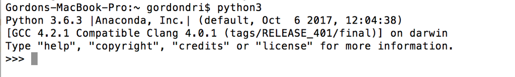

```python
# will not run unless img1 is in the same directory as this notebook
Image(filename="img1.png")
```

> **Step 4: Run a Python program**
> > - Try executing a Python program: `print("Hello World")` and you should see the following picture:

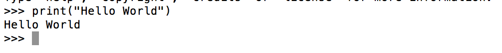

```python
# will not run unless img2 is in the same directory as this notebook
Image(filename="img2.png")
```

> **Step 5: Exit Python**
> > - You can exit the Python engine from your Command Prompt or Terminal by typing in `exit()`

**Verify Conda**: If Conda was sucessfully installed, we should be able to see a complete list of the Packages that were installed through the Package Manager. To check if we can do this:

> **Step 1: Start the Command Prompt** (If not closed from before)

> **Step 2: Run the Conda command**
> > - Type in the command `conda list` and you should see the following picture (with some differences in the version numbers and Path Directory):

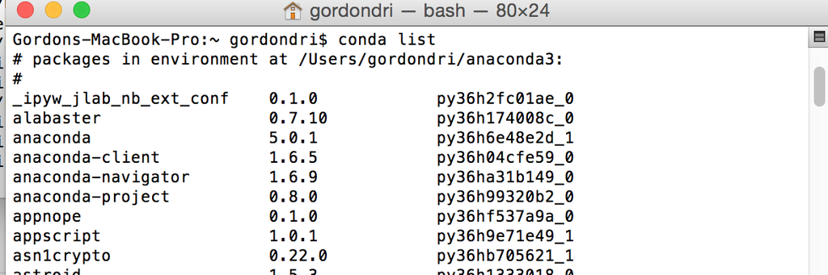

```python
# will not run unless img3 is in the same directory as this notebook
Image(filename="img3.png")
```

# 0.4 Verifying Jupyter Notebook

Now that we have downloaded the Jupyter Notebook IDE through the Anaconda Distribution, we want to run our first Jupyter Notebook.

There are 2 ways of opening a new Jupyter Notebook:

**Method 1:** Open a new session in Terminal or Command Prompt

> **Step 1: Start the Command Prompt** (see instructions above)

> **Step 2: Run the Jupyter Notebook command**
> > - Type in the command `jupyter notebook` at the command prompt
> > - A webpage in your bowser with the URL: http://localhost:8888/tree should be opened
> > - This screen is typically referred to as the Jupyter Notebook Dashboard (see Lecture 1)
> > - This represents a similar file directory that you are used to navigating on your local computer. You will find the current heirarchy of folders on your local machine, similar to the following picture:

[figure not shown]

```python
# will not run unless img4 is in the same directory as this notebook
Image(filename="img4.png")
```

> > - Also, you will notice in the Terminal or Command Prompt window that a list of actions are being archived. See the picture below:

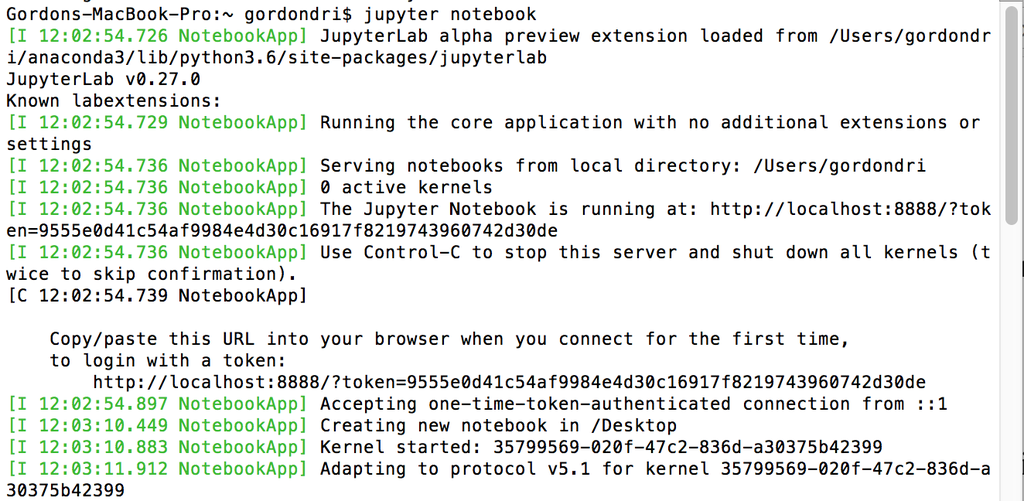

```python
# will not run unless img5 is in the same directory as this notebook
Image(filename="img5.png")
```

**Method 2:** Open a new session in the Anaconda Navigator

> **Step 1: Open the program Anaconda Navigator**
> > - Do this manually by finding the application on your computer and double-clicking the file
> > - OR do this by opening Terminal or Command Prompt (see instructions above) and type `anaconda-Navigator`

> **Step 2: Launch Jupyter Notebook**
> > - You will find the Anaconda Navigator open that should look like the following picture:

[figure not shown]

```python
# will not run unless img6 is in the same directory as this notebook
Image(filename="img6.png")
```

> > - Launch Jupyter Notebook by clicking the 'Launch' button
> > - A webpage will open similar to that above in Image 4
> > - A session in the Terminal or Command Prompt will also activate and you can see an archive of the actions (shown in Image 5 above)

If you were able to complete steps 0.2 - 0.4 without any errors, you are ready to proceed and write your first program in Jupyter Notebook. If not, you can troubleshoot the problems by asking your Course Intructor(s) or simply "Googling" the problem.

NOTE: 99.999% of porgramming problems you encounter have been encountered (and solved) by people before you. You can find a history of these problems and solutions on websites like https://stackoverflow.com/. Simply type your problem in Google and chances are, a thread has been created on Stack Overflow or other, similar sites.

# 0.5 Creating a New Notebook

Now that you have verified the installation of Python, Conda, and Jupyter Notebooks, we can create a new notebook to write our first program.

**Step 1: Launch Jupyter Notebook**

> - After launching Jupyter Notebooks through the Terminal/Command Prompt or manually through the Anaconda Navigator, you will have a browser window opened at this URL: http://localhost:8888/tree.
> - Familiarize yourself with the setup of this page. Notice you are on the "Files" tab which shows a list of your current folders and files on your local machine. You can toggle to the "Running" tab which shows a list of the files that are currently 'running' (more on this later) - this should be empty for now. Ignore the 'Clusters' tab.

**Step 2: Create a new file**

> - Notice you can either click "Upload" or "New" button on the right hand side of your screen. The "Upload" button is used to import a file into your file system. Click the "New" button which expands a drop down menu providing the following options:

[figure not shown]

```python
# will not run unless img7 is in the same directory as this notebook
Image(filename="img7.png")
```

> - Select "Python 3" since we want to run our programs in Python 3. This will open a new Jupyter Notebook in a new tab in your browser. This is where we will be doing all of the programming for this course.
> - In Lecture 1, we will review all the most important components of this window so don't worry if it looks intimidating now
> - For now, ensure that you see the same screen as the picture below:

[figure not shown]

```python
# will not run unless img8 is in the same directory as this notebook
Image(filename="img8.png")
```

# 0.6 Writing Your First Program

Now that you have launched a new Jupyter Notebook, you can begin writing your very first program in Python. You will notice that there is a rectangle highlighted in green that begins with the words "In [ ]:" - this is where you will write your code and is called a cell (more on this in Lecture 1).

- Before writing any code, it is always good practice to name the file you are working in. You can do this by clicking the word "Untitled" next to the Jupyter logo. Rename the file to "FirstProgram"
- Now, we can start coding. In the green rectangle, type the following command: `print("Hello World")` as in the picture below:

[figure not shown]

```python
# will not run unless img9 is in the same directory as this notebook
Image(filename="img9.png")
```

- After writing the code, you have to execute/run/compile the program to see the program's output. You can do this a few different ways:
  > 1. By clicking "Cell" from the Notebook Menubar and selecting "Run Cells" or "Run Cells and Select Below" or "Run Cells and Insert Below" from the drop-down list
  > 2. By clicking the small "play button Run" to the left of the black square in the Notebook Toolbar which is the equivalent of "Run Cells and Select Below"
  > 3. By entering `shift+enter` on your keyboard (more on shortcuts in Lecture 1)
- The result of these methods is the output of your first Python program and should match the picture below:

[figure not shown]

```python
# will not run unless img10 is in the same directory as this notebook
Image(filename="img10.png")
```

# 0.7 Executing Your First Program

In addition to creating your own Jupyter Notebook and writing your own code, you may need to open a Jupyter Notebook written by someone else and execute their code.

To practice doing this, locate the file called `Lecture_0_Part2.ipynb` and save it in a location on your computer that is easily accessible. To access this file in Jupyter Notebooks and execute its Python code, follow these steps:

> **Step 1:** Launch Jupyter Notebook (see instructions above)  
> **Step 2:** In the browser window that has been created, navigate to the location of this file. For example, if you saved the file to your desktop, click the "Desktop" folder to step into that location.  
> **Step 3:** Find the file named `Lecture_0_Part2.ipynb` and click on it. This will launch the file in a new tab in your browser.  
> **Step 4:** Practice running the cells in the file using the 3 methods described above.